# Lista 3

# Lista 3.

## a) Gráfico de controle para a média e amplitude

```r
## Dados
dados <- openxlsx::read.xlsx("Atividade 3.xlsx", sheet = "Planilha2")
# dados <- read.csv("dados_lista03.csv")

## Calculando média e desvio padrão
dados <- dados |>
  dplyr::rowwise() |>
  dplyr::mutate(media = mean(c_across(x1:x5)),
                amplitude = max(c_across(x1:x5)) - min(c_across(x1:x5))) |>
  dplyr::ungroup()
```

### Cálculos para gráfico de controle da média usando amplitude

```r
## Média geral
media_geral <- mean(dados$media)
## Para 5 observações na amostra
a2 <- 0.577
amplitude_geral <- mean(dados$amplitude)
## Limite inferior
LIC <- media_geral - a2 * amplitude_geral
## Limite superior
LSC <- media_geral + a2 * amplitude_geral
```

### Gráfico de controle da média relacionado à amplitude

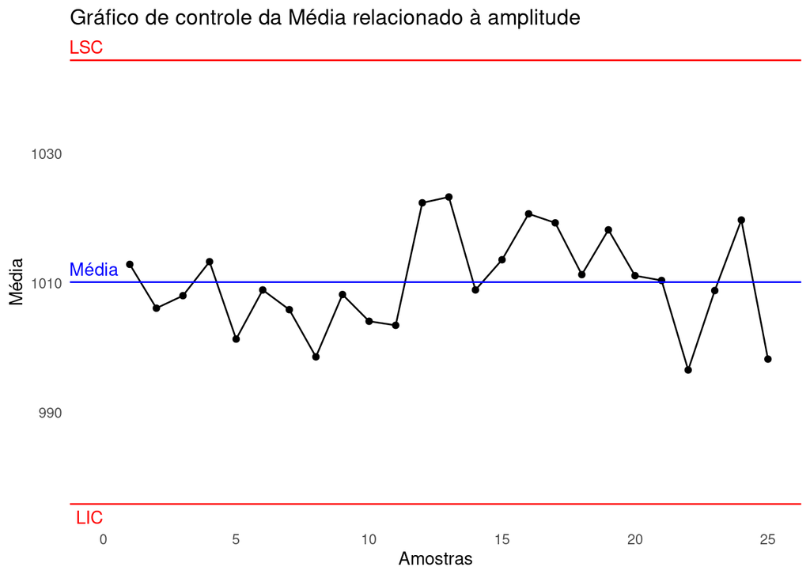

```r
#! warning: F
ggplot(dados, aes(x = Amostra, y = media)) +
  geom_point() +
  geom_line() +
  geom_hline(yintercept = media_geral, color = "blue") +
  geom_hline(yintercept = LSC, color = "red") +
  geom_hline(yintercept = LIC, color = "red") +
  labs(title = "Gráfico de controle da Média relacionado à amplitude",
       x = "Amostras",
       y = "Média") +
  theme_minimal() +
  ggplot2::theme(panel.grid.major = element_blank(),
        panel.grid.minor = element_blank()) +
  ggplot2::annotate("text", x = 0, y = media_geral, label = "Média", color = "blue", vjust = -0.5, hjust = 0.7) +
  ggplot2::annotate("text", x = 0, y = LIC, label = "LIC", color = "red", vjust = 1.5, hjust = 1.0) +
  ggplot2::annotate("text", x = 0, y = LSC, label = "LSC", color = "red", vjust = -0.5, hjust = 1.0)
```

Pela observação do gráfico de média associado à amplitude, não há nenhuma amostra fora dos limites de controle.

### Cálculos para gráfico de controle da amplitude

```r
## Para 5 observações na amostra
d3 <- 0
d4 <-2.114
## Amplitude geral já calculada
## Limite inferior
LIC <- d3 * amplitude_geral
## Limite superior
LSC <- d4 * amplitude_geral
```

## Gráfico de controle da amplitude

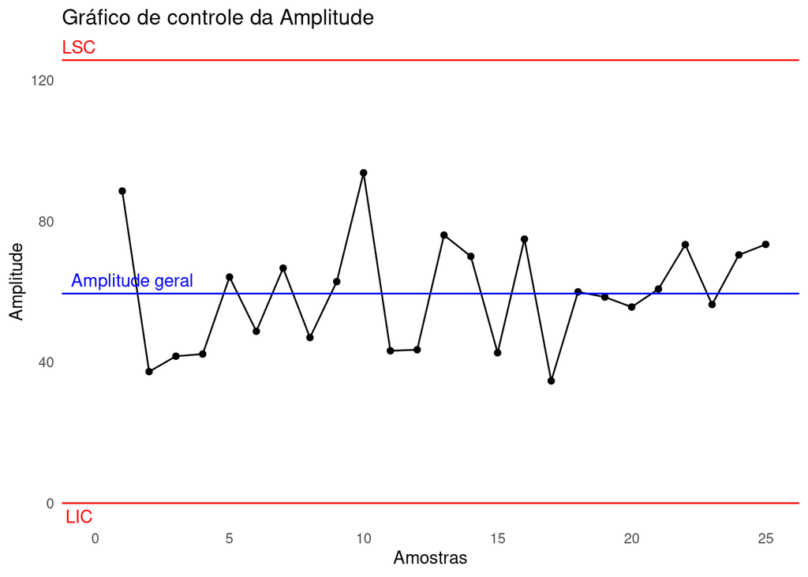

```r
ggplot(dados, aes(x = Amostra, y = amplitude)) +
  geom_point() +
  geom_line() +
  geom_hline(yintercept = amplitude_geral, color = "blue") +
  geom_hline(yintercept = LIC, color = "red") +
  geom_hline(yintercept = LSC, color = "red") +
  labs(title = "Gráfico de controle da Amplitude",
       x = "Amostras",
       y = "Amplitude") +
  theme_minimal() +
  ggplot2::theme(panel.grid.major = element_blank(),
        panel.grid.minor = element_blank()) +
  ggplot2::annotate("text", x = 0, y = amplitude_geral, label = "Amplitude geral", color = "blue", vjust = -0.5, hjust = 0.2) +
  ggplot2::annotate("text", x = 0, y = LIC, label = "LIC", color = "red", vjust = 1.5, hjust = 1.1) +
  ggplot2::annotate("text", x = 0, y = LSC, label = "LSC", color = "red", vjust = -0.5, hjust = 1.0)
```

Pela observação do gráfico de amplitude, não há nenhuma amostra fora dos limites de controle.

## b) Gráfico de controle para a média e desvio padrão

### Cálculos para gráfico de controle da média usando desvio padrão

```r
dados <- dados |>
  dplyr::rowwise() |>
  dplyr::mutate(media = mean(c_across(x1:x5)),
                desvio_padrao = sd(c_across(x1:x5)))

a3 <- 1.427 ## Para 5 observações na amostra
media_geral <- mean(dados$media)
desvio_padrao_geral <- mean(dados$desvio_padrao)
## Limite inferior
LIC <- media_geral - a3 * desvio_padrao_geral
## Limite superior
LSC <- media_geral + a3 * desvio_padrao_geral
```

### Gráfico de controle da média relacionado ao desvio padrão

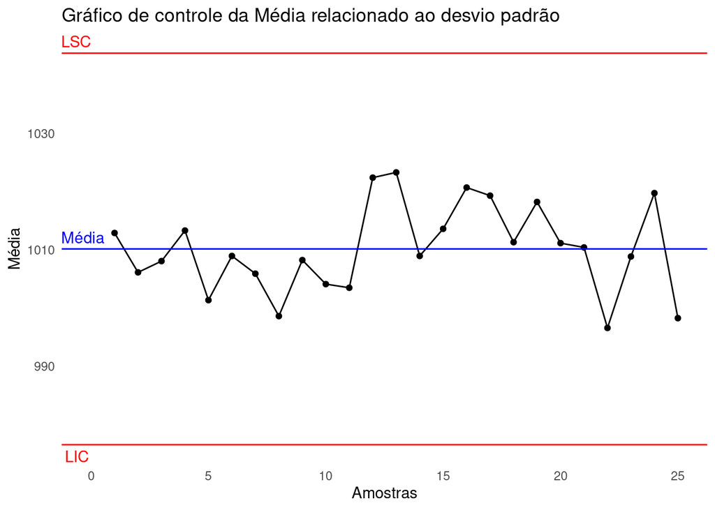

```r
ggplot(dados, aes(x = Amostra, y = media)) +
  geom_point() +
  geom_line() +
  geom_hline(yintercept = media_geral, color = "blue") +
  geom_hline(yintercept = LIC, color = "red") +
  geom_hline(yintercept = LSC, color = "red") +
  labs(title = "Gráfico de controle da Média relacionado ao desvio padrão",
       x = "Amostras",
       y = "Média") +
  theme_minimal() +
  ggplot2::theme(panel.grid.major = element_blank(),
        panel.grid.minor = element_blank()) +
  ggplot2::annotate("text", x = 0, y = media_geral, label = "Média", color = "blue", vjust = -0.5, hjust = 0.7) +
  ggplot2::annotate("text", x = 0, y = LIC, label = "LIC", color = "red", vjust = 1.5, hjust = 1.1) +
  ggplot2::annotate("text", x = 0, y = LSC, label = "LSC", color = "red", vjust = -0.5, hjust = 1.0)
```

Pela observação do gráfico associado ao desvio padrão, não há nenhuma amostra fora dos limites de controle.

### Cálculos para gráfico de controle do desvio padrão

```r
## Para 4 observações na amostra
b3 <- 0
b4 <- 2.266
## Desvio padrão geral já calculado
## Limite inferior
LIC <- b3 * desvio_padrao_geral
## Limite superior
LSC <- b4 * desvio_padrao_geral
```

### Gráfico de controle do desvio padrão

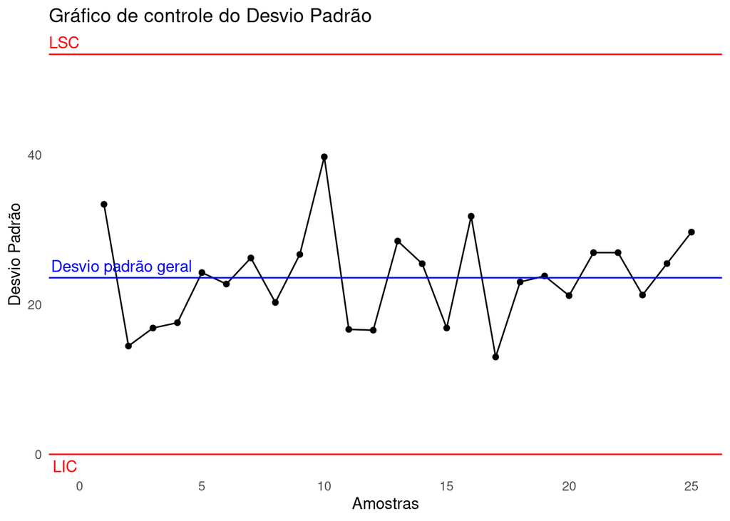

```r
ggplot(dados, aes(x = Amostra, y = desvio_padrao)) +
  geom_point() +
  geom_line() +
  geom_hline(yintercept = desvio_padrao_geral, color = "blue") +
  geom_hline(yintercept = LIC, color = "red") +
  geom_hline(yintercept = LSC, color = "red") +
  labs(title = "Gráfico de controle do Desvio Padrão",
       x = "Amostras",
       y = "Desvio Padrão") +
  theme_minimal() +
  ggplot2::theme(panel.grid.major = element_blank(),
        panel.grid.minor = element_blank()) +
  ggplot2::annotate("text", x = 0, y = desvio_padrao_geral, label = "Desvio padrão geral", color = "blue", vjust = -0.5, hjust = 0.2) +
  ggplot2::annotate("text", x = 0, y = LIC, label = "LIC", color = "red", vjust = 1.5, hjust = 1.1) +
  ggplot2::annotate("text", x = 0, y = LSC, label = "LSC", color = "red", vjust = -0.5, hjust = 1.0)
```

Pela observação do gráfico associado ao desvio padrão, não há nenhuma amostra fora dos limites de controle.

## c) Avaliação dos critérios de decisão

Os critérios de decisão que indicam descontrole na amostra são: I) 1 ou mais pontos acima do LSC ou abaixo do LIC; II) 9 pontos consecutivos na zona C ou no mesmo lado do LC; III) 6 pontos consecutivos, todos aumentando ou todos diminuindo; IV) 14 pontos consecutivos alternando para cima e para baixo; V) 2 de 3 pontos consecutivos na zona A ou além dela; VI) 4 de 5 pontos consecutivos na zona B ou além dela; VII) 15 pontos consecutivos na zona C (tanto acima quanto abaixo do LC); VIII) 8 pontos consecutivos na zona B.

### Calculando as zonas de controle e fazendo os gráficos para as médias

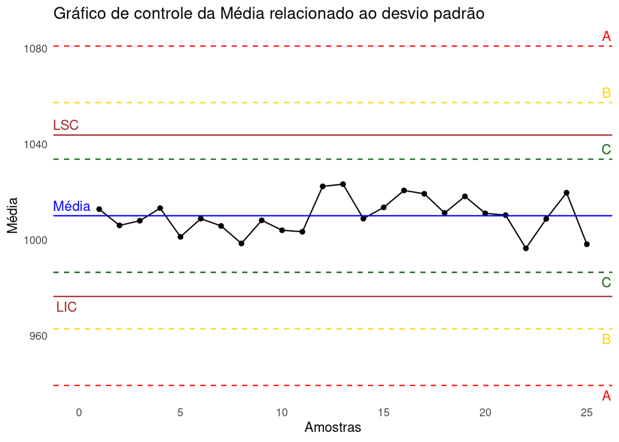

```r
## Calculando as zonas de controle
zona_a_inf <- media_geral - 3 * desvio_padrao_geral
zona_a_sup <- media_geral + 3 * desvio_padrao_geral
zona_b_inf <- media_geral - 2 * desvio_padrao_geral
zona_b_sup <- media_geral + 2 * desvio_padrao_geral
zona_c_inf <- media_geral - desvio_padrao_geral
zona_c_sup <- media_geral + desvio_padrao_geral

## Recalculando os limites de controle
## Limite inferior
LIC <- media_geral - a3 * desvio_padrao_geral
## Limite superior
LSC <- media_geral + a3 * desvio_padrao_geral


## Gráfico de controle da média relacionado ao desvio padrão
ggplot(dados, aes(x = Amostra, y = media)) +
  ggplot2::geom_point() +
  ggplot2::geom_line() +
  ggplot2::geom_hline(yintercept = media_geral, color = "blue") +
  ggplot2::geom_hline(yintercept = c(LSC, LIC), linetype = "solid", color = "brown") +
  ggplot2::geom_hline(yintercept = c(zona_a_sup, zona_a_inf), linetype = "dashed", color = "red") +
  ggplot2::geom_hline(yintercept = c(zona_b_sup, zona_b_inf), linetype = "dashed", color = "gold") +
  ggplot2::geom_hline(yintercept = c(zona_c_sup, zona_c_inf), linetype = "dashed", color = "darkgreen") +
  ggplot2::labs(title = "Gráfico de controle da Média relacionado ao desvio padrão",
       x = "Amostras",
       y = "Média") +
  ggplot2::theme_minimal() +
  ggplot2::theme(panel.grid.major = ggplot2::element_blank(),
                 panel.grid.minor = ggplot2::element_blank()) +
  ggplot2::annotate("text", x = 0, y = media_geral, label = "Média", color = "blue", vjust = -0.5, hjust = 0.7) +
  ggplot2::annotate("text", x = 0, y = LIC, label = "LIC", color = "brown", vjust = 1.5, hjust = 1.1) +
  ggplot2::annotate("text", x = 0, y = LSC, label = "LSC", color = "brown", vjust = -0.5, hjust = 1.0) +
  ggplot2::annotate("text", x = Inf, y = zona_a_sup, label = "A", color = "red", vjust = -0.5, hjust = 1.1) +
  ggplot2::annotate("text", x = Inf, y = zona_a_inf, label = "A", color = "red", vjust = 1.5, hjust = 1.1) +
  ggplot2::annotate("text", x = Inf, y = zona_b_sup, label = "B", color = "gold", vjust = -0.5, hjust = 1.1) +
  ggplot2::annotate("text", x = Inf, y = zona_b_inf, label = "B", color = "gold", vjust = 1.5, hjust = 1.1) +
  ggplot2::annotate("text", x = Inf, y = zona_c_sup, label = "C", color = "darkgreen", vjust = -0.5, hjust = 1.1) +
  ggplot2::annotate("text", x = Inf, y = zona_c_inf, label = "C", color = "darkgreen", vjust = 1.5, hjust = 1.1)
```

### I) 1 ou mais pontos acima do LSC ou abaixo do LIC

Não existem pontos abaixo dos limites inferiores e superiores de controle.

### III) 6 pontos consecutivos, todos aumentando ou todos diminuindo

Não temos 6 pontos consecutivos, todos aumentando ou todos diminuindo.

### IV) 14 pontos consecutivos alternando para cima e para baixo

Não temos 14 pontos consecutivos alternando para cima e para baixo.

### V) 2 de 3 pontos consecutivos na zona A ou além dela

Não temos 2 de 3 pontos consecutivos na zona A ou além dela.

### VI) 4 de 5 pontos consecutivos na zona B ou além dela

Não temos 4 de 5 pontos consecutivos na zona B ou além dela.

### VII) 15 pontos consecutivos na zona C (tanto acima quanto abaixo do LC)

Temos 15 pontos consecutivos na zona C, indicando uma possível falta de controle.

### VIII) 8 pontos consecutivos na zona B

Não temos 8 pontos consecutivos na zona B.

## d) Dado que as especificações são 1000 +- 20 gramas encontre o Cp e Cpk

Cálculo do $C_p$ e $C_{pk}$

```r
## Limite inferior e superior de especificação
LIE <- 1000 - 20
LSE <- 1000 + 20

## Cálculo do Cp
Cp <- (LSE - LIE) / (6 * desvio_padrao_geral)

## Cálculo do Cpk
Cpk <- min((LSE - media_geral) / (3 * desvio_padrao_geral),
           (media_geral - LIE) / (3 * desvio_padrao_geral))
```

Avaliando os resultados temos que o $C_p$ é 0.2824561, indicando que o processo é incapaz de atender a especificação e o $C_{pk}$ é 0.1388422, também indicando que o processo é incapaz de atender a especificação.

## e) Considere as 125 observações como uma única amostra e faça o GC para medidas individuais

### Cálculos para gráfico de controle para medidas individuais

```r
## Ajustando base de dados
dados_individuais <- dados |>
  dplyr::select(-media, -desvio_padrao, - amplitude) |>
  tidyr::pivot_longer(cols = -Amostra, names_to = "Variavel", values_to = "Valor") |>
  dplyr::select(-Variavel, -Amostra, x = Valor)

## Calculando a média móvel
dados_individuais <- dados_individuais |>
  dplyr::mutate(amplitude_movel = abs(x-lag(x)))

## Média geral
media_geral <- mean(dados_individuais$x)
## Média das amplitudes móveis
amplitude_media_geral <- mean(dados_individuais$amplitude_movel, na.rm = TRUE)
d2 <- 1.128 ## Para 2 observações (medidas individuais)

## Limites de controle
LIC <- media_geral - 3 * (amplitude_media_geral / d2)
LSC <- media_geral + 3 * (amplitude_media_geral / d2)
```

### Gráfico de controle para medidas individuais

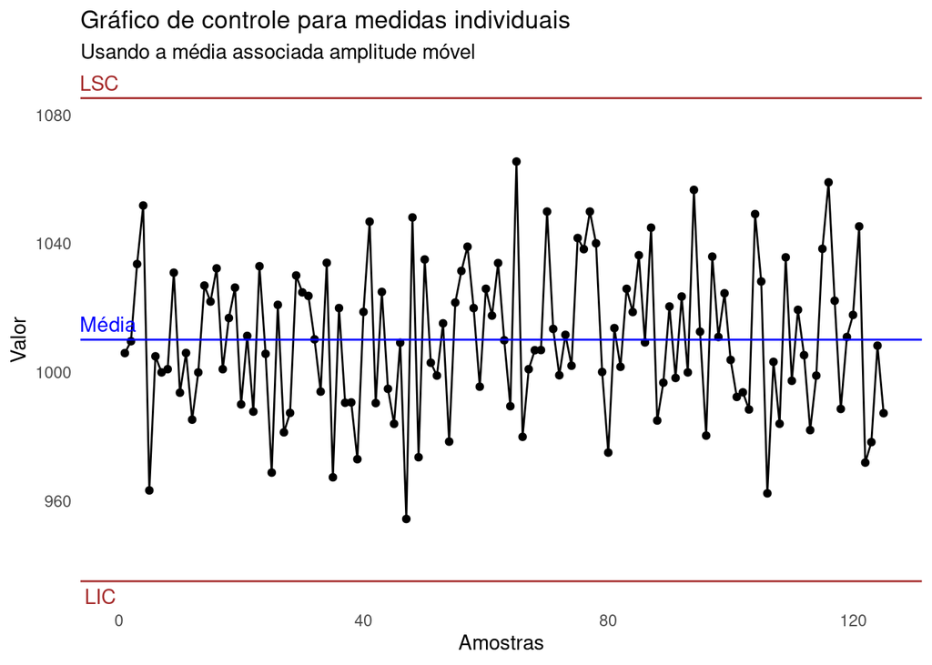

```r
ggplot(dados_individuais, aes(x = 1:nrow(dados_individuais), y = x)) +
  ggplot2::geom_point() +
  ggplot2::geom_line() +
  ggplot2::geom_hline(yintercept = media_geral, color = "blue") +
  ggplot2::geom_hline(yintercept = c(LSC, LIC), linetype = "solid", color = "brown") +
  ggplot2::labs(title = "Gráfico de controle para medidas individuais",
       subtitle = "Usando a média associada amplitude móvel",
       x = "Amostras",
       y = "Valor") +
  ggplot2::theme_minimal() +
  ggplot2::theme(panel.grid.major = element_blank(),
        panel.grid.minor = element_blank()) +
  ggplot2::annotate("text", x = 0, y = media_geral, label = "Média", color = "blue", vjust = -0.5, hjust = 0.7) +
  ggplot2::annotate("text", x = 0, y = LIC, label = "LIC", color = "brown", vjust = 1.5, hjust = 1.1) +
  ggplot2::annotate("text", x = 0, y = LSC, label = "LSC", color = "brown", vjust = -0.5, hjust = 1.0)
```